# 02 — $p_T$ bins: visualização microscópica

Este notebook usa exatamente as tabelas diferenciais de Pb–Pb já mapeadas:

- `Table01.csv`: espectro diferencial de píons;
- `Table03.csv`: espectro diferencial de kaons;
- `Table05.csv`: espectro diferencial de prótons;
- `Table07.csv`: razão diferencial $K/\pi(p_T)$;
- `Table09.csv`: razão diferencial $p/\pi(p_T)$;
- `Table11.csv` e `Table13.csv`: razões integradas, usadas apenas para conexão com o notebook anterior.

A ideia física é sair da leitura macroscópica por centralidade/multiplicidade e entrar na forma microscópica da distribuição em momento transversal.

## 1. Imports, diretórios e parser HEPData

```python
from pathlib import Path
import csv
import re

import numpy as np
import pandas as pd
import matplotlib.pyplot as plt

plt.rcParams["figure.figsize"] = (8, 5)
plt.rcParams["font.family"] = "DejaVu Sans"

DATA_DIR = Path("..")
PB_PB_DIR = DATA_DIR / "Pb-Pb"

# Fallback para quando os CSVs estão na mesma pasta do notebook
if not PB_PB_DIR.exists():
    PB_PB_DIR = Path(".")

def split_hepdata_blocks(path):
    """
    Lê um arquivo CSV estilo HEPData contendo múltiplos blocos.
    Retorna uma lista de tuplas:
        (metadata, dataframe)
    """
    path = Path(path)
    lines = path.read_text(encoding="utf-8").splitlines()

    blocks = []
    meta = {}
    header = None
    rows = []

    def flush_block():
        nonlocal header, rows
        if header is not None and rows:
            df = pd.DataFrame(rows, columns=header)

            # Converte colunas numéricas quando possível
            for col in df.columns:
                converted = pd.to_numeric(df[col], errors="coerce")
                if converted.notna().mean() > 0.5:
                    df[col] = converted

            blocks.append((meta.copy(), df))

        header = None
        rows = []

    for raw in lines:
        line = raw.strip()

        if not line:
            continue

        if line.startswith("#:"):
            content = line[2:].strip()

            # Se um novo bloco de centralidade começa depois de dados, fecha o bloco anterior
            if "CENTRALITY" in content and header is not None and rows:
                flush_block()

            if ",,," in content:
                key, value = content.split(",,,", 1)
                meta[key.strip()] = value.strip()
            elif ":" in content:
                key, value = content.split(":", 1)
                meta[key.strip()] = value.strip()
            elif "," in content:
                parts = next(csv.reader([content]))
                if parts:
                    meta[parts[0].strip()] = " | ".join(p.strip() for p in parts[1:])

            continue

        parts = [p.strip() for p in next(csv.reader([line]))]

        # Se aparece um novo cabeçalho depois de linhas de dados, fecha bloco anterior
        if header is not None and rows:
            first = parts[0]
            if any(ch.isalpha() for ch in first) or "$" in first:
                flush_block()

        if header is None:
            header = parts
        else:
            if len(parts) == len(header):
                rows.append(parts)

    flush_block()
    return blocks


def centrality_midpoint(label):
    """
    Converte uma string como '0.0-5.0' no ponto médio 2.5.
    """
    nums = re.findall(r"\d+\.?\d*", str(label))
    if len(nums) >= 2:
        return 0.5 * (float(nums[0]) + float(nums[1]))
    return np.nan


def get_centrality(meta):
    """
    Extrai o label de centralidade do metadata do bloco.
    """
    return meta.get("CENTRALITY [pct]", "unknown")


def get_pt(df):
    """
    Retorna pT central. Nas tabelas já há uma coluna central de pT.
    """
    pt_col = [c for c in df.columns if "p_{T}" in c and "LOW" not in c and "HIGH" not in c][0]
    return df[pt_col].values


def get_pt_edges(df):
    low_col = [c for c in df.columns if "p_{T}" in c and "LOW" in c][0]
    high_col = [c for c in df.columns if "p_{T}" in c and "HIGH" in c][0]
    return df[low_col].values, df[high_col].values


def get_observable_col(df):
    """
    Retorna a primeira coluna numérica que não seja pT nem erro.
    """
    excluded = ["p_{T}", "LOW", "HIGH", "stat", "syst"]
    candidates = [
        c for c in df.columns
        if not any(e in c for e in excluded)
        and pd.api.types.is_numeric_dtype(df[c])
    ]
    if not candidates:
        raise ValueError("Não encontrei coluna de observável.")
    return candidates[0]


def get_errors(df):
    stat = df["stat. +"].values if "stat. +" in df.columns else None
    syst = df["syst. +"].values if "syst. +" in df.columns else None
    uncorr = df["syst. uncorr. +"].values if "syst. uncorr. +" in df.columns else None
    return stat, syst, uncorr


def load_table(name):
    path = PB_PB_DIR / name
    if not path.exists():
        raise FileNotFoundError(f"Não encontrei {path}. Ajuste PB_PB_DIR.")
    return split_hepdata_blocks(path)


def summarize_blocks(blocks, table_name):
    print(f"{table_name}: {len(blocks)} blocos")
    print("Centralidades:", [get_centrality(meta) for meta, _ in blocks])
```

## 2. Carregar exatamente as tabelas de interesse

Aqui não vamos inspecionar todas as tabelas. Vamos direto às tabelas físicas que queremos analisar.

```python
# =========================
# Tabelas diferenciais Pb-Pb
# =========================

pion_blocks = load_table("Table01.csv")    # pi+ + pi- spectra, Pb-Pb
kaon_blocks = load_table("Table03.csv")    # K+ + K- spectra, Pb-Pb
proton_blocks = load_table("Table05.csv")  # p + pbar spectra, Pb-Pb

kpi_blocks = load_table("Table07.csv")     # K/pi(pT), Pb-Pb
ppi_blocks = load_table("Table09.csv")     # p/pi(pT), Pb-Pb

# Tabelas integradas para manter conexão com o notebook 01
kpi_int_blocks = load_table("Table11.csv")
ppi_int_blocks = load_table("Table13.csv")

summarize_blocks(pion_blocks, "Table01 — pion spectra")
summarize_blocks(kaon_blocks, "Table03 — kaon spectra")
summarize_blocks(proton_blocks, "Table05 — proton spectra")
summarize_blocks(kpi_blocks, "Table07 — K/pi(pT)")
summarize_blocks(ppi_blocks, "Table09 — p/pi(pT)")
```

```
Table01 — pion spectra: 10 blocos
Centralidades: ['0.0-5.0', '5.0-10.0', '10.0-20.0', '20.0-30.0', '30.0-40.0', '40.0-50.0', '50.0-60.0', '60.0-70.0', '70.0-80.0', '80.0-90.0']
Table03 — kaon spectra: 10 blocos
Centralidades: ['0.0-5.0', '5.0-10.0', '10.0-20.0', '20.0-30.0', '30.0-40.0', '40.0-50.0', '50.0-60.0', '60.0-70.0', '70.0-80.0', '80.0-90.0']
Table05 — proton spectra: 10 blocos
Centralidades: ['0.0-5.0', '5.0-10.0', '10.0-20.0', '20.0-30.0', '30.0-40.0', '40.0-50.0', '50.0-60.0', '60.0-70.0', '70.0-80.0', '80.0-90.0']
Table07 — K/pi(pT): 10 blocos
Centralidades: ['0.0-5.0', '5.0-10.0', '10.0-20.0', '20.0-30.0', '30.0-40.0', '40.0-50.0', '50.0-60.0', '60.0-70.0', '70.0-80.0', '80.0-90.0']
Table09 — p/pi(pT): 10 blocos
Centralidades: ['0.0-5.0', '5.0-10.0', '10.0-20.0', '20.0-30.0', '30.0-40.0', '40.0-50.0', '50.0-60.0', '60.0-70.0', '70.0-80.0', '80.0-90.0']
```

## 3. Espectros diferenciais de píons

Os píons são os hádrons mais leves e dominam a multiplicidade final. O espectro $p_T$ dos píons mostra a parte mais abundante da produção soft.

A queda forte com $p_T$ indica que a maior parte das partículas é produzida em baixo momento transversal. Em colisões centrais, a normalização é maior porque o sistema produzido é maior.

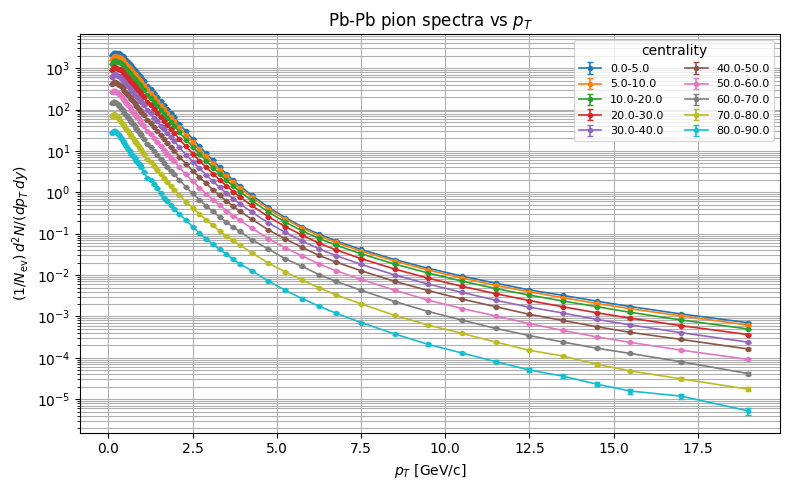

```python
def plot_species_spectra(blocks, species_label, title):
    fig, ax = plt.subplots(figsize=(8,5))

    for meta, df in blocks:
        cent = get_centrality(meta)
        pt = get_pt(df)
        y_col = get_observable_col(df)
        y = df[y_col].values
        stat, _, _ = get_errors(df)

        ax.errorbar(
            pt,
            y,
            yerr=stat,
            fmt="o-",
            capsize=2,
            linewidth=1.2,
            markersize=3,
            label=cent,
        )

    ax.set_yscale("log")
    ax.set_xlabel(r"$p_T$ [GeV/c]")
    ax.set_ylabel(r"$(1/N_{\rm ev})\, d^2N/(dp_T\,dy)$")
    ax.set_title(title)
    ax.grid(True, which="both")
    ax.legend(title="centrality", fontsize=8, ncol=2)
    plt.tight_layout()
    plt.show()


plot_species_spectra(
    pion_blocks,
    r"$\pi^+ + \pi^-$",
    r"Pb-Pb pion spectra vs $p_T$"
)
```

## 4. Espectros diferenciais de kaons e prótons

Comparando píons, kaons e prótons, começamos a enxergar a dependência com massa e composição química.

- Kaons carregam strangeness, então são importantes para estudar produção de estranheza.
- Prótons são bárions, então carregam informação diferente da componente mesônica.
- A forma em $p_T$ também é sensível a radial flow: espécies mais pesadas tendem a ser empurradas para $p_T$ mais alto.

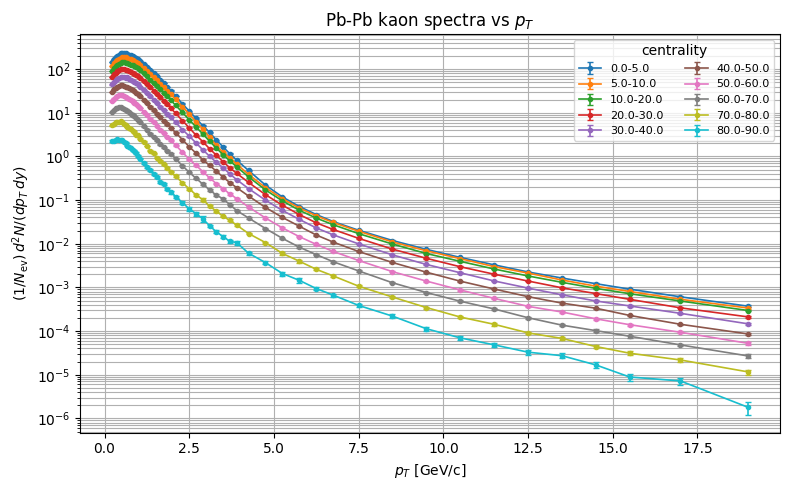

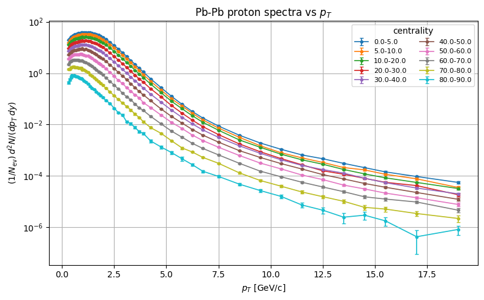

```python
plot_species_spectra(
    kaon_blocks,
    r"$K^+ + K^-$",
    r"Pb-Pb kaon spectra vs $p_T$"
)

plot_species_spectra(
    proton_blocks,
    r"$p + \bar p$",
    r"Pb-Pb proton spectra vs $p_T$"
)
```

## 5. Espectros selecionados com faixas sistemáticas

Agora mantemos apenas algumas centralidades representativas para enxergar melhor as faixas sistemáticas.

A barra vertical nos pontos representa o erro estatístico. A faixa representa o erro sistemático total.

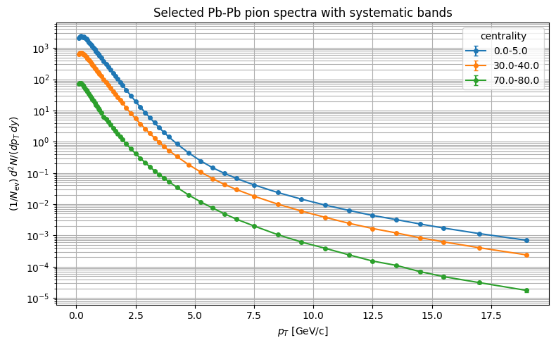

```python
def select_blocks_by_centrality(blocks, wanted=("0.0-5.0", "30.0-40.0", "70.0-80.0")):
    selected = []
    for meta, df in blocks:
        cent = get_centrality(meta)
        if cent in wanted:
            selected.append((meta, df))
    return selected


def plot_selected_species_with_systematics(blocks, title, wanted=("0.0-5.0", "30.0-40.0", "70.0-80.0")):
    selected = select_blocks_by_centrality(blocks, wanted)

    fig, ax = plt.subplots(figsize=(8,5))

    for meta, df in selected:
        cent = get_centrality(meta)
        pt = get_pt(df)
        y_col = get_observable_col(df)
        y = df[y_col].values
        stat, syst, uncorr = get_errors(df)

        if syst is not None:
            ax.fill_between(
                pt,
                y - syst,
                y + syst,
                alpha=0.15,
            )

        ax.errorbar(
            pt,
            y,
            yerr=stat,
            fmt="o-",
            capsize=2,
            linewidth=1.5,
            markersize=4,
            label=cent,
        )

    ax.set_yscale("log")
    ax.set_xlabel(r"$p_T$ [GeV/c]")
    ax.set_ylabel(r"$(1/N_{\rm ev})\, d^2N/(dp_T\,dy)$")
    ax.set_title(title)
    ax.grid(True, which="both")
    ax.legend(title="centrality")
    plt.tight_layout()
    plt.show()


plot_selected_species_with_systematics(
    pion_blocks,
    r"Selected Pb-Pb pion spectra with systematic bands"
)
```

## 6. Razões diferenciais $K/\pi(p_T)$ e $p/\pi(p_T)$

As razões diferenciais removem parte da normalização global e mostram como a composição hadrônica depende do momento transversal.

A pergunta agora não é apenas “quanto kaon/próton foi produzido?”, mas:

> em quais regiões de $p_T$ kaons e prótons se tornam relativamente mais importantes em relação aos píons?

"Bump bariônico" é favorecido por centralidade

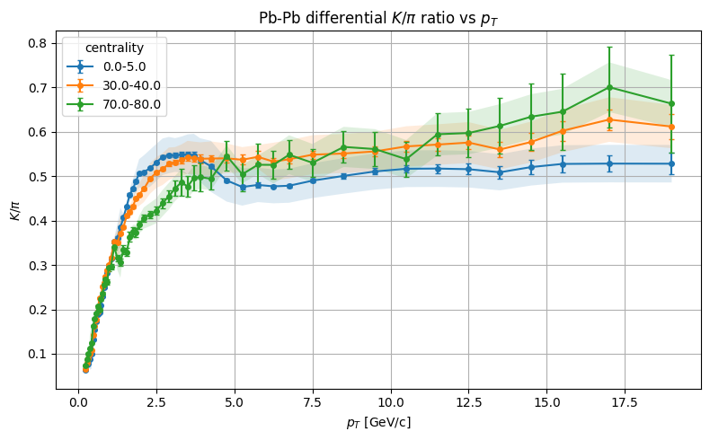

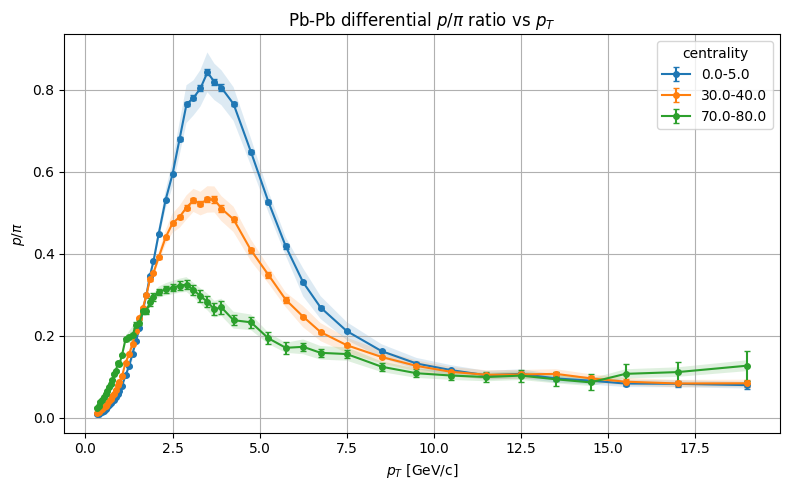

```python
def plot_ratio_blocks(blocks, ylabel, title, wanted=("0.0-5.0", "30.0-40.0", "70.0-80.0")):
    selected = select_blocks_by_centrality(blocks, wanted)

    fig, ax = plt.subplots(figsize=(8,5))

    for meta, df in selected:
        cent = get_centrality(meta)
        pt = get_pt(df)
        y_col = get_observable_col(df)
        y = df[y_col].values
        stat, syst, uncorr = get_errors(df)

        if syst is not None:
            ax.fill_between(
                pt,
                y - syst,
                y + syst,
                alpha=0.15,
            )

        ax.errorbar(
            pt,
            y,
            yerr=stat,
            fmt="o-",
            capsize=2,
            linewidth=1.5,
            markersize=4,
            label=cent,
        )

    ax.set_xlabel(r"$p_T$ [GeV/c]")
    ax.set_ylabel(ylabel)
    ax.set_title(title)
    ax.grid(True)
    ax.legend(title="centrality")
    plt.tight_layout()
    plt.show()


plot_ratio_blocks(
    kpi_blocks,
    r"$K/\pi$",
    r"Pb-Pb differential $K/\pi$ ratio vs $p_T$"
)

plot_ratio_blocks(
    ppi_blocks,
    r"$p/\pi$",
    r"Pb-Pb differential $p/\pi$ ratio vs $p_T$"
)
```

## 7. Conexão com as razões integradas

As razões integradas comprimem toda a estrutura em $p_T$ em um único número por centralidade. Agora podemos interpretar esses números como uma projeção macroscópica da estrutura diferencial.

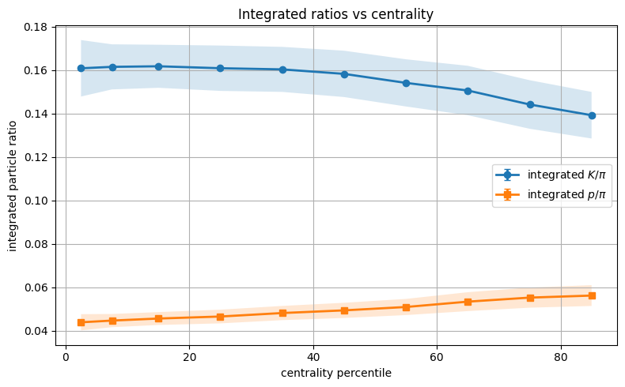

```python
# =========================
# Razões integradas, repetindo a conexão com o notebook 01
# =========================

nch_df = kpi_int_blocks[0][1].copy()
kpi_int_df = kpi_int_blocks[1][1].copy()
ppi_int_df = ppi_int_blocks[1][1].copy()

cent_labels = nch_df["Cent [ptc.]"]
cent_mid = np.array([centrality_midpoint(c) for c in cent_labels])

kpi_col = get_observable_col(kpi_int_df)
ppi_col = get_observable_col(ppi_int_df)

fig, ax = plt.subplots(figsize=(8,5))

for df, col, marker, label in [
    (kpi_int_df, kpi_col, "o-", r"integrated $K/\pi$"),
    (ppi_int_df, ppi_col, "s-", r"integrated $p/\pi$"),
]:
    y = df[col].values
    stat, syst, uncorr = get_errors(df)

    if syst is not None:
        ax.fill_between(
            cent_mid,
            y - syst,
            y + syst,
            alpha=0.18,
        )

    ax.errorbar(
        cent_mid,
        y,
        yerr=stat,
        fmt=marker,
        capsize=3,
        linewidth=2,
        label=label,
    )

ax.set_xlabel("centrality percentile")
ax.set_ylabel("integrated particle ratio")
ax.set_title(r"Integrated ratios vs centrality")
ax.grid(True)
ax.legend()
plt.tight_layout()
plt.show()
```

## 8. Leitura física provisória

O dataset possui duas camadas:

1. Camada integrada: mostra como a composição global muda com centralidade/multiplicidade.
2. Camada diferencial: mostra em que região de $p_T$ essa mudança acontece.

Em baixo $p_T$, os espectros refletem principalmente produção soft, bulk e expansão coletiva. Em $p_T$ mais alto, começa a aparecer a física de processos hard e a comparação com pp se torna necessária para discutir supressão nuclear e $R_{AA}$.

## 9. Carregar baseline pp

```python
# =========================
# Tabelas diferenciais pp
# =========================

PP_DIR = DATA_DIR / "pp"
if not PP_DIR.exists():
    PP_DIR = Path(".")

def load_pp_table(name):
    path = PP_DIR / name
    if not path.exists():
        raise FileNotFoundError(f"Não encontrei {path}. Ajuste PP_DIR.")
    return split_hepdata_blocks(path)

pp_pion_blocks = load_pp_table("Table02.csv")
pp_kaon_blocks = load_pp_table("Table04.csv")
pp_proton_blocks = load_pp_table("Table06.csv")
pp_kpi_blocks = load_pp_table("Table08.csv")
pp_ppi_blocks = load_pp_table("Table10.csv")

summarize_blocks(pp_pion_blocks, "Table02 — pp pion spectra")
summarize_blocks(pp_kaon_blocks, "Table04 — pp kaon spectra")
summarize_blocks(pp_proton_blocks, "Table06 — pp proton spectra")
summarize_blocks(pp_kpi_blocks, "Table08 — pp K/pi(pT)")
summarize_blocks(pp_ppi_blocks, "Table10 — pp p/pi(pT)")
```

```
Table02 — pp pion spectra: 1 blocos
Centralidades: ['unknown']
Table04 — pp kaon spectra: 1 blocos
Centralidades: ['unknown']
Table06 — pp proton spectra: 1 blocos
Centralidades: ['unknown']
Table08 — pp K/pi(pT): 1 blocos
Centralidades: ['unknown']
Table10 — pp p/pi(pT): 1 blocos
Centralidades: ['unknown']
```

## 10. Função de comparação Pb–Pb vs pp

```python
def first_block(blocks):
    return blocks[0][1].copy()

def plot_pbpb_selected_vs_pp(
    pbpb_blocks,
    pp_blocks,
    title,
    ylabel=None,
    wanted=("0.0-5.0", "30.0-40.0", "70.0-80.0"),
    logy=False,
):
    fig, ax = plt.subplots(figsize=(8,5))

    selected = select_blocks_by_centrality(pbpb_blocks, wanted)

    for meta, df in selected:
        cent = get_centrality(meta)
        pt = get_pt(df)
        y_col = get_observable_col(df)
        y = df[y_col].values
        stat, syst, _ = get_errors(df)

        if syst is not None:
            ax.fill_between(pt, y - syst, y + syst, alpha=0.12)

        ax.errorbar(
            pt,
            y,
            yerr=stat,
            fmt="o-",
            capsize=2,
            linewidth=1.5,
            markersize=4,
            label=f"Pb-Pb {cent}%",
        )

    pp_df = first_block(pp_blocks)
    pp_pt = get_pt(pp_df)
    pp_y_col = get_observable_col(pp_df)
    pp_y = pp_df[pp_y_col].values
    pp_stat, pp_syst, _ = get_errors(pp_df)

    if pp_syst is not None:
        ax.fill_between(pp_pt, pp_y - pp_syst, pp_y + pp_syst, alpha=0.18)

    ax.errorbar(
        pp_pt,
        pp_y,
        yerr=pp_stat,
        fmt="D--",
        capsize=2,
        linewidth=1.5,
        markersize=4,
        label="pp",
    )

    if logy:
        ax.set_yscale("log")

    ax.set_xlabel(r"$p_T$ [GeV/c]")
    ax.set_ylabel(ylabel if ylabel is not None else "observable")
    ax.set_title(title)
    ax.grid(True, which="both" if logy else "major")
    ax.legend(fontsize=8)
    plt.tight_layout()
    plt.show()
```

## 11. Espectros diferenciais: Pb–Pb vs pp

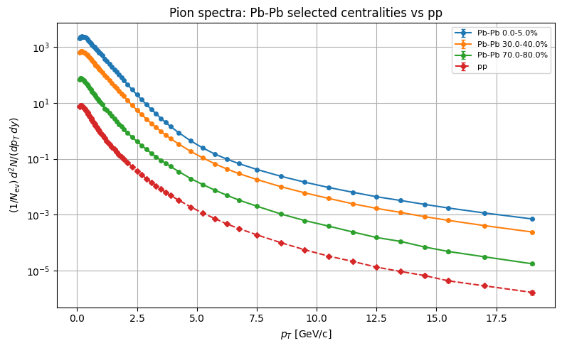

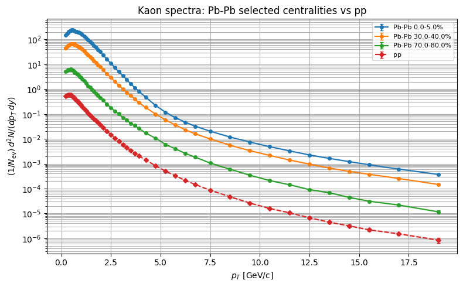

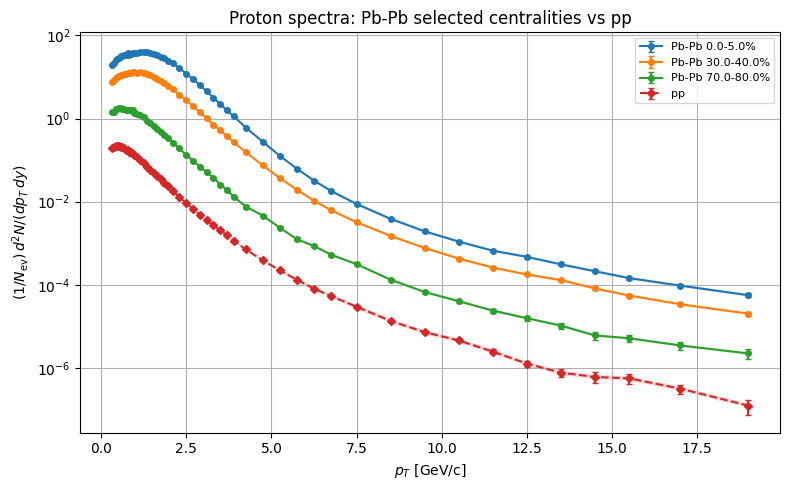

```python
plot_pbpb_selected_vs_pp(
    pion_blocks,
    pp_pion_blocks,
    title=r"Pion spectra: Pb-Pb selected centralities vs pp",
    ylabel=r"$(1/N_{\rm ev})\, d^2N/(dp_T\,dy)$",
    logy=True,
)

plot_pbpb_selected_vs_pp(
    kaon_blocks,
    pp_kaon_blocks,
    title=r"Kaon spectra: Pb-Pb selected centralities vs pp",
    ylabel=r"$(1/N_{\rm ev})\, d^2N/(dp_T\,dy)$",
    logy=True,
)

plot_pbpb_selected_vs_pp(
    proton_blocks,
    pp_proton_blocks,
    title=r"Proton spectra: Pb-Pb selected centralities vs pp",
    ylabel=r"$(1/N_{\rm ev})\, d^2N/(dp_T\,dy)$",
    logy=True,
)
```

## 12. Razões diferenciais: Pb–Pb vs pp

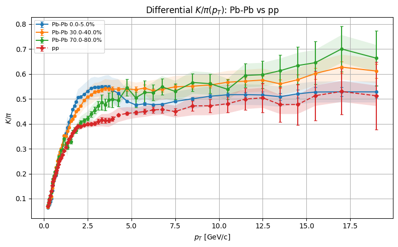

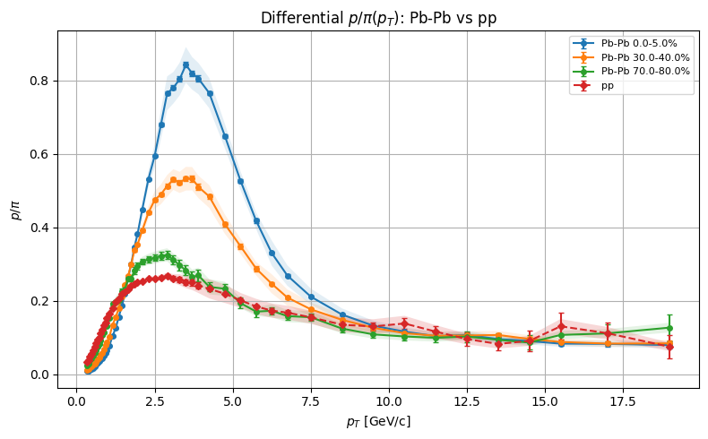

```python
plot_pbpb_selected_vs_pp(
    kpi_blocks,
    pp_kpi_blocks,
    title=r"Differential $K/\pi(p_T)$: Pb-Pb vs pp",
    ylabel=r"$K/\pi$",
    logy=False,
)

plot_pbpb_selected_vs_pp(
    ppi_blocks,
    pp_ppi_blocks,
    title=r"Differential $p/\pi(p_T)$: Pb-Pb vs pp",
    ylabel=r"$p/\pi$",
    logy=False,
)
```

## Comparação com pp

Agora usamos pp como baseline físico.

A interpretação é:

- pp representa uma colisão sem um meio nuclear grande e duradouro;
- Pb–Pb central representa um sistema grande, denso e coletivo;
- Pb–Pb periférico deve se aproximar mais do comportamento pp.

Essa comparação ajuda a separar duas perguntas:

1. A forma do espectro é apenas consequência da cinemática/hadronização comum?
2. Ou existe uma modificação associada ao meio coletivo de Pb–Pb?

Nos espectros absolutos, a comparação direta ainda mistura volume e número de colisões. Por isso, a interpretação mais limpa do setor hard normalmente exige (R_{AA}). Já nas razões (K/\pi) e (p/\pi), parte da normalização global cancela, então fica mais fácil enxergar mudanças de composição hadrônica.

Em particular, o bump de (p/\pi) em (p_T) intermediário em Pb–Pb central, quando comparado com pp, é uma assinatura forte de física coletiva e/ou recombination/coalescence.